# Principle Component Analysis III

## Handwritten Letters

[figure not shown]

```r
g_data <- d[d$letter == "g", ]
plot_letter(g_data[19, ])
```

## Mean letter

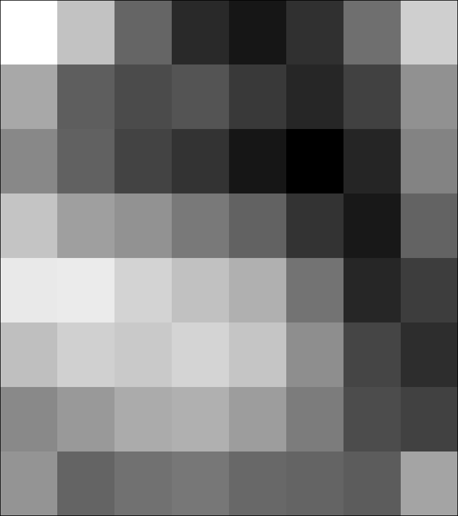

```r
g_mean <- colSums(g_data[, -1])/nrow(g_data)
plot_letter(g_mean, hasletter = FALSE)
```

## Dimension reduction

Can we capture most of the structure in a smaller number of dimensions?

\[m < p ?\]

## Plotting the PCs

```r
pca1 <- prcomp(g_data[, -1])
d <- as.data.frame(pca1$x)
library(ggplot2)
p1 <- ggplot(d, aes(x = PC1, y = PC2)) +
  geom_point(alpha = .4)
```

## Plotting the PCs

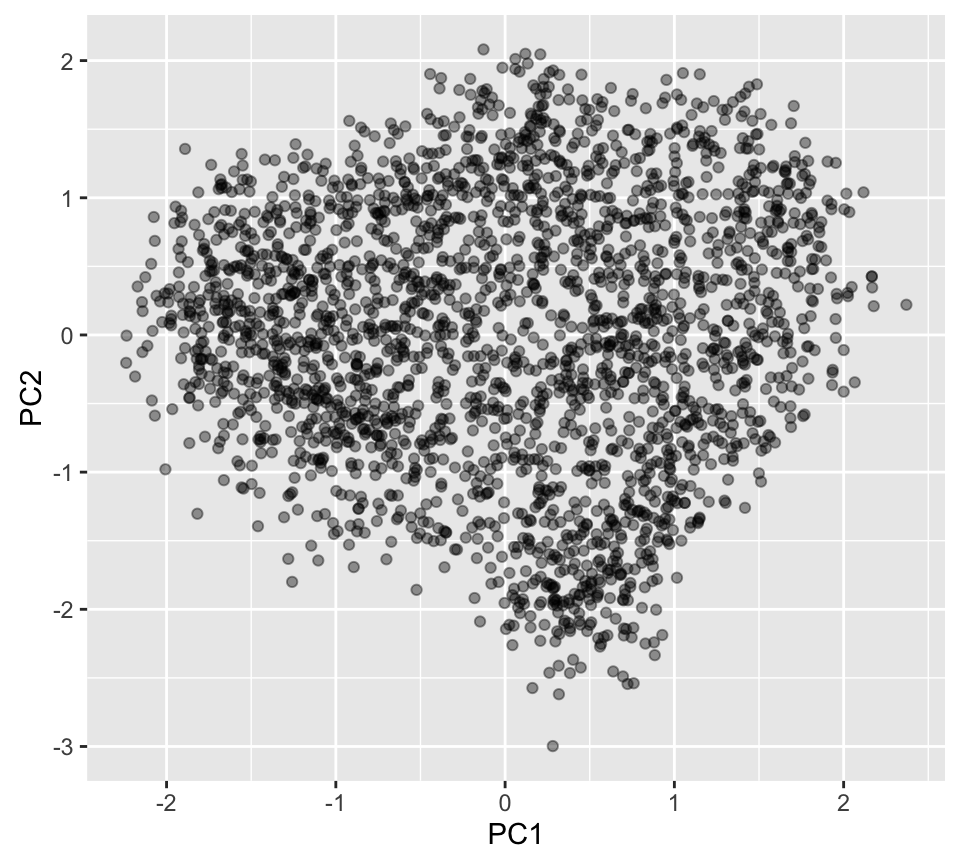

## Scree plot

Used to visualize the proportion of variance explained (PVE) by each PC.

## Scree plot

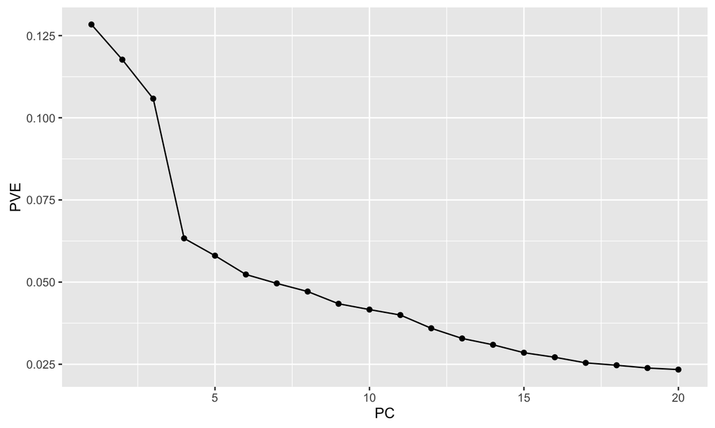

## Scree plot

A good amount of the structure in the data resides in the first 4 PCs (PVE: 0.4151918)

But what do these PCs actually mean?

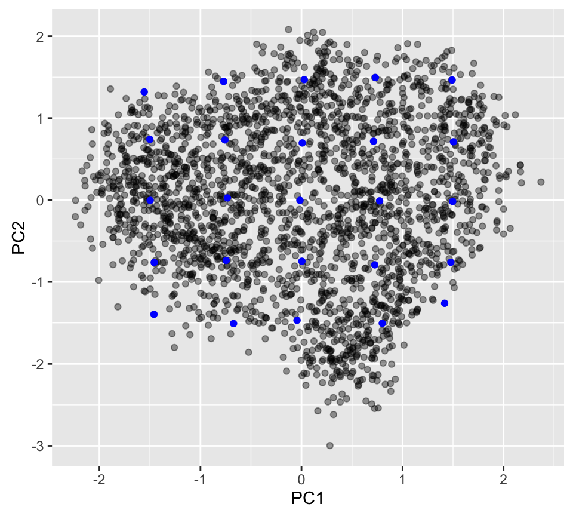

[figure not shown]

[figure not shown]

[figure not shown]

[figure not shown]

[figure not shown]

[figure not shown]

[figure not shown]

[figure not shown]

[figure not shown]

[figure not shown]

[figure not shown]

[14 more figures not shown]

## What do the PCs mean?

Difficult to tell due to

- Low resolution
- Lots of information to synthesize

But there is another way to learn about these first two PCs…

## Practice

1. Extract the loadings (`rotation`) from your PCA object and used `plot_letter()` to plot your first several PCs. What variation they seem to be capturing?
2. Generate a 5x5 plot of the images of letters sampled from a regular grid across the first two PCs (use `pc_grid()` in the updated code file from last class.) Do these conform with the direct images of the loadings?

First, reset graphical parameters.

```r
dev.off()
```

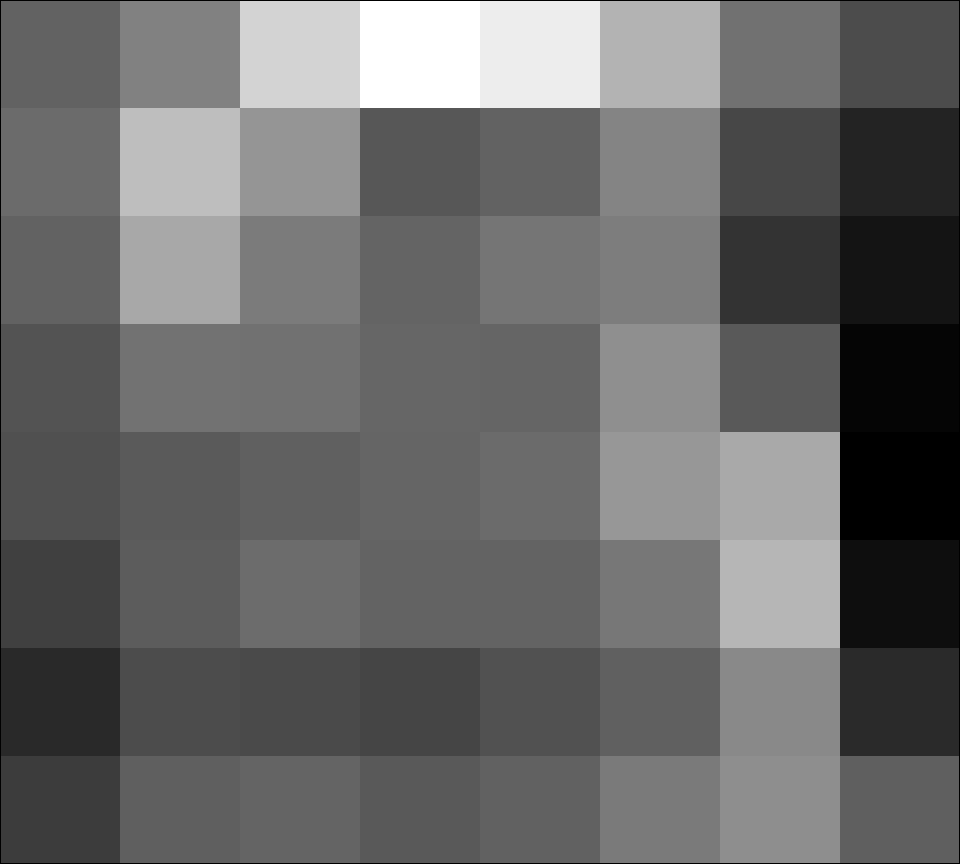

```r
plot_letter(pca1$rotation[, 1], hasletter = FALSE)
```

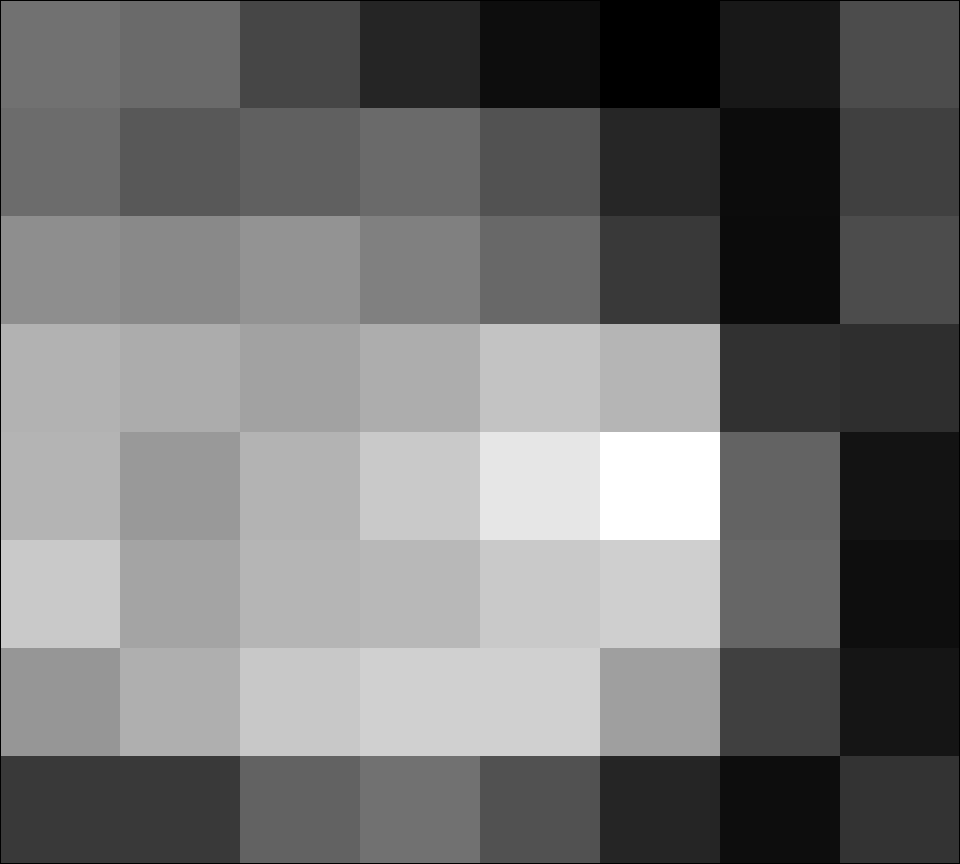

```r
plot_letter(pca1$rotation[, 2], hasletter = FALSE)
```

[figure not shown]

[figure not shown]

[figure not shown]

[figure not shown]

[figure not shown]

[figure not shown]

[figure not shown]

[figure not shown]

[figure not shown]

[figure not shown]

[figure not shown]

[figure not shown]

[13 more figures not shown]

```r
pc_grid(pca1, g_data)
```